# San Francisco 49ers Offense: Scouting Report

**Public data.** Built from nflverse (nflfastR play-by-play, NGS participation, FTN charting), mapped onto the PFF GamePBP layout. Run concepts, PFF success codes, yards after contact and receiver alignment are not in this source; see *What nflverse cannot cover* at the end.

**Sample:** 8 games (Sep 10, 2026 to Nov 08, 2026) · 453 offensive plays · Opponents: ARZ, ATL, DEN, LA, LV, MIA, SEA, WAS  
**Source:** SF_2026_nflverse_GamePBP.csv · Generated Nov 10, 2026 18:07 · Success = standard yardage definition · EPA = nflfastR model

57%Pass rate

51%Neutral early-down pass rate

+0.19EPA / play

59%Success rate

53%3rd-down conversion

3%Sack rate

11%Explosive play rate

## Key findings

### Tendencies

- Passes on 57% of all plays and 51% of neutral early-down plays (1st/2nd down, outside 2-minute drills).
- QB alignment is a strong run/pass key: under center they run 65% of the time (n=233); in shotgun they pass 81% (n=214).
- Tell: Shotgun + 3rd Down -> pass 90% of the time (n=61, 95% lower bound 80%).
- Tell: 2nd Down + Extra Long (11+) -> pass 95% of the time (n=20, 95% lower bound 76%).
- Tell: Shotgun -> pass 81% of the time (n=214, 95% lower bound 76%).
- Tell: 3rd Down + Medium (4-6) -> pass 91% of the time (n=22, 95% lower bound 72%).
- Run game is built on Middle and Right Guard: 56% of carries.
- Predictability: knowing personnel, alignment, down and distance lifts a defense’s run/pass guess from 57% to 72% (leave-one-out).

### Strengths

- Most efficient run gap: Left Tackle, +0.11 EPA/carry, 4.5 YPC, 59% success (n=17).
- Primary target: G. Kittle (#85) (TE), 23% target share, 37 catches for 457 yards, +0.25 EPA/target, 21 first downs.
- Most efficient receiver: M. Evans (#5) (WR), +1.02 EPA/target on 39 targets, aDOT 14.6, 2.7 YAC/rec.
- Lead back C. McCaffrey (#23): 52% of carries, 4.5 YPC, 57% success. Favorite gap: Middle.
- Most total value: M. Evans (#5), 39.9 total EPA on 39 touches + targets (500 scrimmage yards).
- Deep shots (20+ air yards): 9% of targets, 55% complete, +1.15 EPA/target (n=20).

### Vulnerabilities

- Play action: 23% of dropbacks, +0.08 EPA/play vs +0.37 without (n=58 vs 198).
- Least efficient run gap: Right Guard, -0.08 EPA/carry, stuffed (0 or fewer yards) on 7% (n=27).
- On 3rd and Long (7-10) they convert only 31% (n=13); they pass 92% of the time there. Overall 3rd-down conversion: 53%.
- High-volume, low-return target: C. McCaffrey (#23) (HB), 20% of targets but +0.08 EPA/target and 80% catch rate.

**n** = the number of plays (or carries / targets) behind a number, i.e. the sample size. Findings are generated by fixed rules (see Methodology) and include sample sizes. Treat any rate built on fewer than 10 plays as anecdotal.

## 1. Personnel run/pass tendencies

[figure not shown]

Not available for this data set.

453 plays with no recorded personnel are left out of this section.

## 2. Down-and-distance tendencies

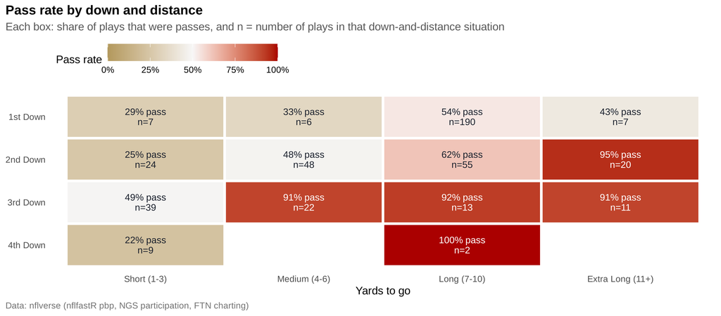

| Down | To go | Plays | Pass % | Run EPA | Pass EPA | Success |
| --- | --- | --- | --- | --- | --- | --- |
| 1st Down | Short (1-3) | 7 | 29% | +0.24 | +0.65 | 57% |
| 1st Down | Medium (4-6) | 6 | 33% | +0.11 | -0.03 | 67% |
| 1st Down | Long (7-10) | 190 | 54% | -0.05 | +0.16 | 62% |
| 1st Down | Extra Long (11+) | 7 | 43% | +0.26 | +0.29 | 43% |
| 2nd Down | Short (1-3) | 24 | 25% | +0.09 | +0.19 | 71% |
| 2nd Down | Medium (4-6) | 48 | 48% | -0.11 | +0.23 | 56% |
| 2nd Down | Long (7-10) | 55 | 62% | +0.24 | +0.67 | 58% |
| 2nd Down | Extra Long (11+) | 20 | 95% | -0.56 | +0.43 | 45% |
| 3rd Down | Short (1-3) | 39 | 49% | +0.27 | +0.18 | 64% |
| 3rd Down | Medium (4-6) | 22 | 91% | -0.64 | +0.36 | 50% |
| 3rd Down | Long (7-10) | 13 | 92% | +0.00 | -0.68 | 31% |
| 3rd Down | Extra Long (11+) | 11 | 91% | +0.33 | +1.37 | 45% |
| 4th Down | Short (1-3) | 9 | 22% | +0.19 | +2.91 | 78% |
| 4th Down | Long (7-10) | 2 | 100% | n/a | -0.23 | 50% |

**By field position** (yards from the opponent’s end zone):

| Zone | Plays | Pass % | EPA/play | Success |
| --- | --- | --- | --- | --- |
| Goal to Go (1-10) | 44 | 48% | +0.41 | 61% |
| Red Zone (11-20) | 42 | 60% | +0.53 | 60% |
| Plus Territory (21-50) | 156 | 54% | +0.08 | 59% |
| Own Territory (51-80) | 174 | 60% | +0.13 | 58% |
| Backed Up (81-99) | 37 | 54% | +0.27 | 57% |

## 3. QB alignment tendencies

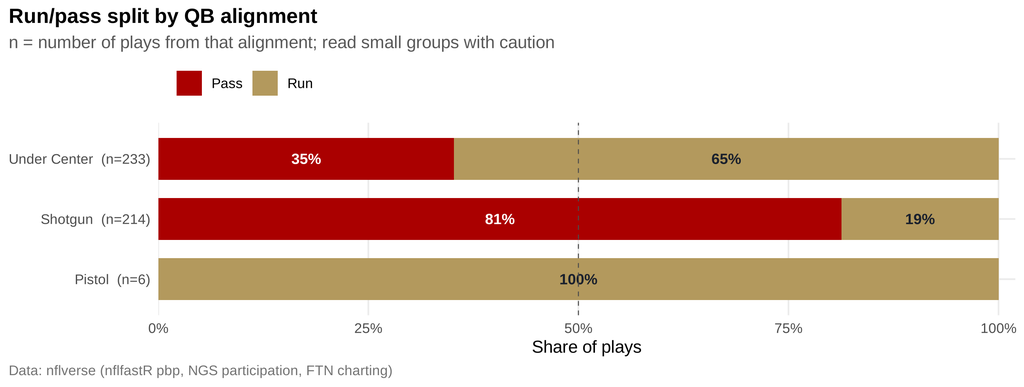

| Alignment | Plays | Snap % | Pass % | Run EPA | Pass EPA | Run YPC | Pass Y/P |
| --- | --- | --- | --- | --- | --- | --- | --- |
| Under Center | 233 | 51% | 35% | +0.09 | +0.27 | 4.3 | 7.5 |
| Shotgun | 214 | 47% | 81% | -0.14 | +0.32 | 5.2 | 8.3 |
| Pistol | 6 | 1% | 0% | -0.02 | n/a | 3.5 | n/a |

**Alignment by personnel** (groupings with enough plays):

Not available for this data set.

## 4. Run gap and direction: frequency and effectiveness

nflverse does not chart blocking schemes, so runs are grouped by the gap and side the play-by-play records (end / tackle / guard / middle). This answers *where* they run, not *which concept*.

[figure not shown]

| Concept | Carries | Share | YPC | Median | Success | EPA/carry | Stuff % | Explosive % | Under center % | Top personnel |
| --- | --- | --- | --- | --- | --- | --- | --- | --- | --- | --- |
| Middle | 84 | 43% | 4.2 | 3.0 | 63% | +0.08 | 17% | 12% | 73% | Unknown |
| Right Guard | 27 | 14% | 4.7 | 3.0 | 56% | -0.08 | 7% | 15% | 81% | Unknown |
| Left Guard | 23 | 12% | 3.4 | 3.0 | 57% | +0.05 | 13% | 4% | 78% | Unknown |
| Left End | 21 | 11% | 6.6 | 6.0 | 52% | +0.00 | 24% | 29% | 76% | Unknown |
| Left Tackle | 17 | 9% | 4.5 | 5.0 | 59% | +0.11 | 6% | 6% | 76% | Unknown |
| Right End | 17 | 9% | 3.7 | 3.0 | 53% | -0.06 | 18% | 6% | 88% | Unknown |
| Right Tackle | 8 | 4% | 5.1 | 5.0 | 75% | +0.09 | 0% | 12% | 75% | Unknown |

## 5. Third-down behavior and key targets

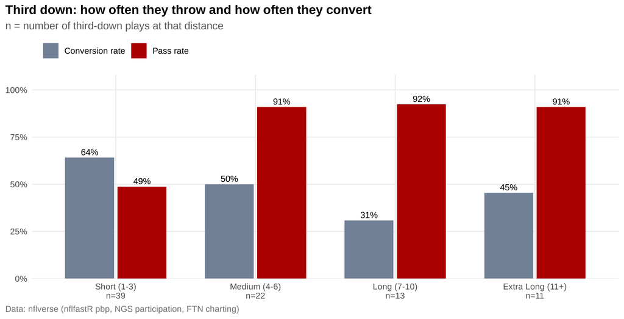

| To go | Plays | Pass % | Conv % | Conv 95% CI | EPA/play | Gun/Pistol % | Avg air yds | Sack % |
| --- | --- | --- | --- | --- | --- | --- | --- | --- |
| Short (1-3) | 39 | 49% | 64% | 48%-77% | +0.22 | 41% | 9.6 | 5% |
| Medium (4-6) | 22 | 91% | 50% | 31%-69% | +0.27 | 95% | 9.1 | 0% |
| Long (7-10) | 13 | 92% | 31% | 13%-58% | -0.63 | 100% | 13.7 | 0% |
| Extra Long (11+) | 11 | 91% | 45% | 21%-72% | +1.27 | 100% | 9.0 | 10% |

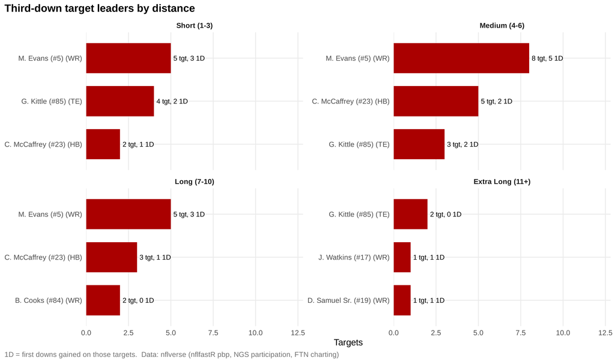

All third downs

| Player | Pos | Targets | Share | Rec | Yds | 1st downs | EPA/tgt | aDOT |
| --- | --- | --- | --- | --- | --- | --- | --- | --- |
| M. Evans (#5) | WR | 19 | 34% | 12 | 206 | 12 | +1.00 | 13.8 |
| C. McCaffrey (#23) | HB | 10 | 18% | 5 | 48 | 4 | +0.09 | 5.4 |
| G. Kittle (#85) | TE | 9 | 16% | 6 | 67 | 4 | +0.16 | 9.6 |
| J. Cowing (#4) | WR | 5 | 9% | 2 | 14 | 1 | -1.29 | 7.4 |
| J. Watkins (#17) | WR | 4 | 7% | 3 | 85 | 3 | +0.98 | 17.0 |
| B. Cooks (#84) | WR | 3 | 5% | 0 | 0 | 0 | -1.51 | 11.0 |
| D. Robinson (#11) | WR | 2 | 4% | 0 | 0 | 0 | -1.58 | 9.5 |
| D. Samuel Sr. (#19) | WR | 2 | 4% | 2 | 22 | 2 | +2.07 | 8.5 |

## 6. Most effective players and how they produce

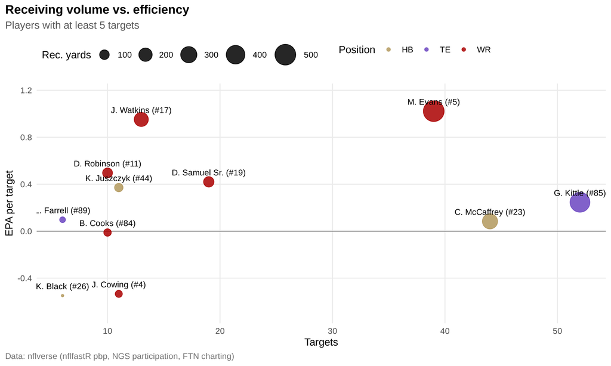

| Player | Pos | Tgt | Share | Rec | Yds | Catch % | Y/Tgt | aDOT | YAC/Rec | EPA/Tgt | 1D |
| --- | --- | --- | --- | --- | --- | --- | --- | --- | --- | --- | --- |
| G. Kittle (#85) | TE | 52 | 23% | 37 | 457 | 71% | 8.8 | 8.0 | 6.4 | +0.25 | 21 |
| C. McCaffrey (#23) | HB | 44 | 20% | 35 | 262 | 80% | 6.0 | 2.8 | 5.5 | +0.08 | 13 |
| M. Evans (#5) | WR | 39 | 17% | 27 | 500 | 69% | 12.8 | 14.6 | 2.7 | +1.02 | 25 |
| D. Samuel Sr. (#19) | WR | 19 | 8% | 15 | 118 | 79% | 6.2 | 2.9 | 5.0 | +0.42 | 5 |
| J. Watkins (#17) | WR | 13 | 6% | 10 | 224 | 77% | 17.2 | 16.5 | 5.1 | +0.95 | 9 |
| J. Cowing (#4) | WR | 11 | 5% | 5 | 52 | 45% | 4.7 | 12.1 | 1.4 | -0.53 | 3 |
| K. Juszczyk (#44) | HB | 11 | 5% | 8 | 76 | 73% | 6.9 | 7.7 | 4.1 | +0.37 | 6 |
| B. Cooks (#84) | WR | 10 | 4% | 5 | 58 | 50% | 5.8 | 10.8 | 2.8 | -0.01 | 5 |
| D. Robinson (#11) | WR | 10 | 4% | 8 | 106 | 80% | 10.6 | 10.7 | 2.2 | +0.50 | 6 |
| K. Black (#26) | HB | 6 | 3% | 3 | 4 | 50% | 0.7 | -2.0 | 4.7 | -0.55 | 0 |
| L. Farrell (#89) | TE | 6 | 3% | 3 | 33 | 50% | 5.5 | 8.5 | 5.3 | +0.10 | 2 |
| J. Brendel (#64) | OL | 1 | 0% | 1 | 2 | 100% | 2.0 | -1.0 | 3.0 | -0.44 | 0 |

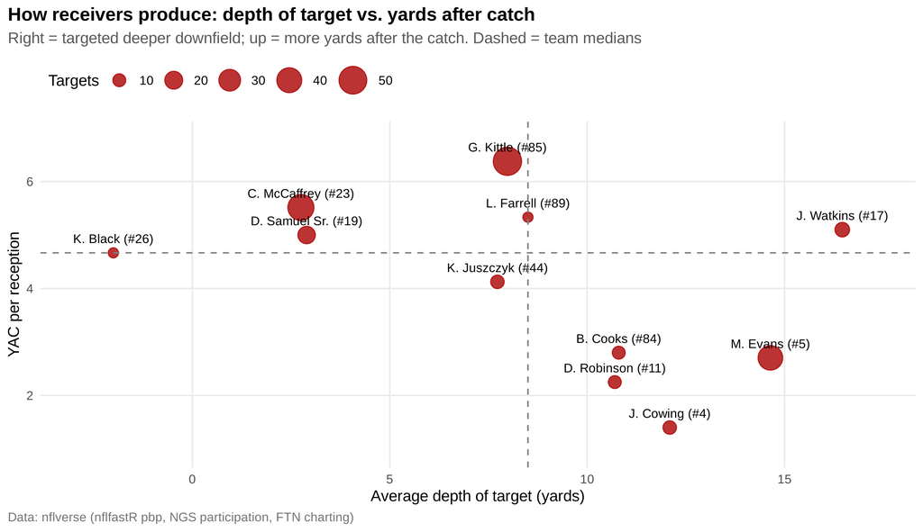

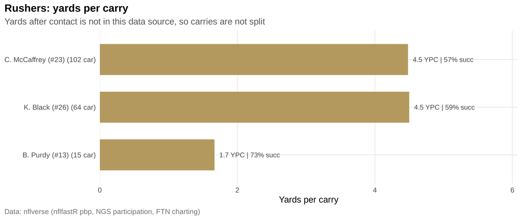

| Player | Carries | Share | Yds | YPC | Success | EPA/car | YBC | YACo | Explosive % | Stuff % | Top concept |
| --- | --- | --- | --- | --- | --- | --- | --- | --- | --- | --- | --- |
| C. McCaffrey (#23) | 102 | 52% | 457 | 4.5 | 57% | +0.13 | n/a | n/a | 13% | 11% | Middle |
| K. Black (#26) | 64 | 32% | 288 | 4.5 | 59% | -0.06 | n/a | n/a | 9% | 20% | Middle |
| B. Purdy (#13) | 15 | 8% | 25 | 1.7 | 73% | -0.02 | n/a | n/a | 0% | 20% | Middle |
| D. Samuel Sr. (#19) | 9 | 5% | 78 | 8.7 | 56% | -0.30 | n/a | n/a | 44% | 11% | Left End |
| J. James (#29) | 4 | 2% | 17 | 4.2 | 50% | -0.09 | n/a | n/a | 0% | 0% | Right Guard |
| J. Cowing (#4) | 2 | 1% | 12 | 6.0 | 100% | +0.59 | n/a | n/a | 50% | 0% | Left End |
| K. Juszczyk (#44) | 1 | 1% | 4 | 4.0 | 100% | +0.38 | n/a | n/a | 0% | 0% | Middle |

**Total offensive value** (rushing + receiving EPA; QB passing EPA is credited to targets):

| Player | Carries | Targets | Scrimmage yds | Rush EPA | Rec EPA | Total EPA | EPA/opp |
| --- | --- | --- | --- | --- | --- | --- | --- |
| M. Evans (#5) | 0 | 39 | 500 | 0.0 | 39.9 | 39.9 | +1.02 |
| C. McCaffrey (#23) | 102 | 44 | 719 | 13.2 | 3.7 | 16.9 | +0.12 |
| G. Kittle (#85) | 0 | 52 | 457 | 0.0 | 12.8 | 12.8 | +0.25 |
| J. Watkins (#17) | 0 | 13 | 224 | 0.0 | 12.4 | 12.4 | +0.95 |
| D. Samuel Sr. (#19) | 9 | 19 | 196 | -2.7 | 8.0 | 5.3 | +0.19 |
| D. Robinson (#11) | 0 | 10 | 106 | 0.0 | 5.0 | 5.0 | +0.50 |
| K. Juszczyk (#44) | 1 | 11 | 80 | 0.4 | 4.1 | 4.5 | +0.37 |
| K. Hodge (#86) | 0 | 1 | 17 | 0.0 | 1.0 | 1.0 | +0.98 |

## 7. Passing-game context

| Split | Value | Dropbacks | Share | EPA/play | Success | Y/P |
| --- | --- | --- | --- | --- | --- | --- |
| Play action | No | 198 | 77% | +0.37 | 59% | 8.4 |
| Play action | Yes | 58 | 23% | +0.08 | 55% | 6.7 |
| Screen | No | 235 | 92% | +0.34 | 59% | 8.1 |
| Screen | Yes | 21 | 8% | -0.06 | 52% | 6.6 |

Targets by depth

| Depth | Targets | Share | Comp % | Y/Tgt | EPA/Tgt | INT % |
| --- | --- | --- | --- | --- | --- | --- |
| Behind LOS | 39 | 17% | 85% | 4.7 | -0.31 | 3% |
| Short (1-9) | 100 | 45% | 79% | 7.5 | +0.44 | 1% |
| Intermediate (10-19) | 65 | 29% | 55% | 9.7 | +0.37 | 5% |
| Deep (20+) | 20 | 9% | 55% | 17.9 | +1.15 | 0% |

Results by defensive coverage faced (5+ dropbacks)

| Coverage | Dropbacks | Share | EPA/play | Success |
| --- | --- | --- | --- | --- |
| Unknown | 256 | 100% | +0.30 | 58% |

## 8. Pre-snap tells and predictability

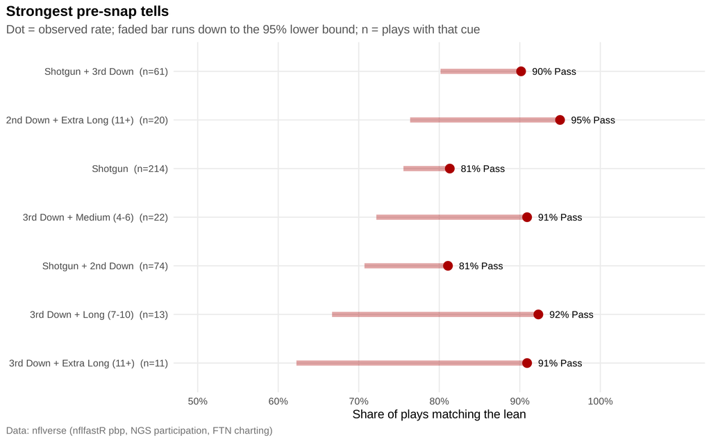

Always guessing the more common play type is right **57%** of the time. Using personnel, alignment, down and distance bucket (leave-one-out cell rates) is right **72%** of the time, a lift of **15%**.

## Methodology and data notes

How the sample was built

| Step | Plays |
| --- | --- |
| Offensive snaps in file | 506 |
| Run or pass plays (drops penalties / no-plays) | 478 |
| Downs 1-4 (drops PATs / 2-pt tries) | 478 |
| Excluding garbage time | 462 |
| Excluding QB kneels and spikes | 453 |

### What nflverse cannot cover (or only approximates)

- Personnel / formation / coverage / routes: nflverse participation data covers only 0% of these plays (it is typically posted after the season), so those sections are mostly empty.
- Run concepts: nflverse has no blocking-scheme charting (inside zone, duo, power …). Section 4 groups runs by gap and direction instead (e.g. ‘Left Tackle’, ‘Middle’).
- PFF success codes (pff_OFFSUCCESS): not in nflverse. Success uses the standard 40/60/100 yardage rule only.
- EPA / EP: nflfastR’s public model, not PFF’s. Values are close in spirit but not identical.
- Yards after contact: not in nflverse, so the before/after-contact split for rushers is unavailable (yards per carry is shown instead).
- Receiver alignment (slot / wide / backfield): not in nflverse. ‘Main align’ is blank.
- Personnel is counted from the roster positions of the 11 players on the field (RB+FB, TE). A WR listed as TE on the roster counts as a TE. ’(*)’ = 6+ offensive linemen.
- Garbage time is approximated with win probability (second half, pre-snap WP below 0.01% or above 99.99%). Calibrated against a licensed PFF sample.
- 2-minute flag: inside the final 2:00 of either half (PFF’s 4-minute flag has no equivalent).
- Pressure is NGS ‘was_pressure’ (yes/no); time to pressure is not available.

Column names below refer to the PFF GamePBP layout the nflverse data was mapped onto.

- **Pass play / dropback:** `pff_RUNPASS = "P"`, which includes sacks and QB scrambles. **Run:** `"R"`. Penalties and no-plays (`"X"`) are removed.
- **QB alignment:** Pistol if `pff_PISTOL` is set, otherwise Shotgun if `pff_SHOTGUN` is set, otherwise Under Center.
- **Success (standard):** gaining at least 40% of the distance on 1st down, 60% on 2nd, and 100% on 3rd/4th, or earning a first down. PFF success codes are not in nflverse, so only the standard rule is used.
- **First down:** `pff_FIRSTDOWNGAINED = 1` or yards gained ≥ distance.
- **EPA:** `pff_EXPECTEDPOINTSADDED` as provided. Passing EPA is attributed to the targeted receiver.
- **Target:** a pass play with a recorded receiver, excluding sacks and scrambles. **Receiving yards:** yards gained on completions.
- **Explosive:** runs of 10+ yards, passes of 20+ yards.
- **Field zone:** `ABSOLUTEYARDLINE` is yards to the opponent’s end zone (so 1–20 is the red zone).
- **Tell:** a pre-snap cue (personnel, alignment, down, distance, or combinations) with at least 10 plays where one play type reaches 80%. The 95% lower bound uses a Wilson interval.
- **Intervals:** rates show 95% Wilson intervals; run-concept EPA shows ±1 standard error. With samples this small, most differences between groups are not statistically distinguishable; the report shows n everywhere so readers can judge.
- **Garbage time** excluded: TRUE. **2-minute drills** excluded: FALSE. **Personnel “(*)“** marks a jumbo package (an extra offensive lineman replaces a skill player); merged into the base grouping: FALSE.

**Data checks:**

- Player names from SF_2026_roster.csv (nflverse weekly rosters 2026)

Blank numeric cells (for example yards after catch on runs) are expected and listed for completeness.

Reproducibility: source file MD5 c20b5d30eaca12721178a3a674da44f1. Every table in this report is also saved as CSV and in one Excel workbook next to this file.